# Practical Machine Learning Course Project

## Algorithms

There are too many variables to reasonably choose features using exploratory plots; therefore, I will use decision tree (rpart) and random forest (rf), both of which are suited to very large datasets with a large number of variables, where the outcome is a factor and the features are automatically selected.

Because random forest with repeated k-fold cross-validation was too computationally intensive for my computer, I instead use k-fold cross-validation with k=5. Prior to the training, the seed is set for reproducibility.

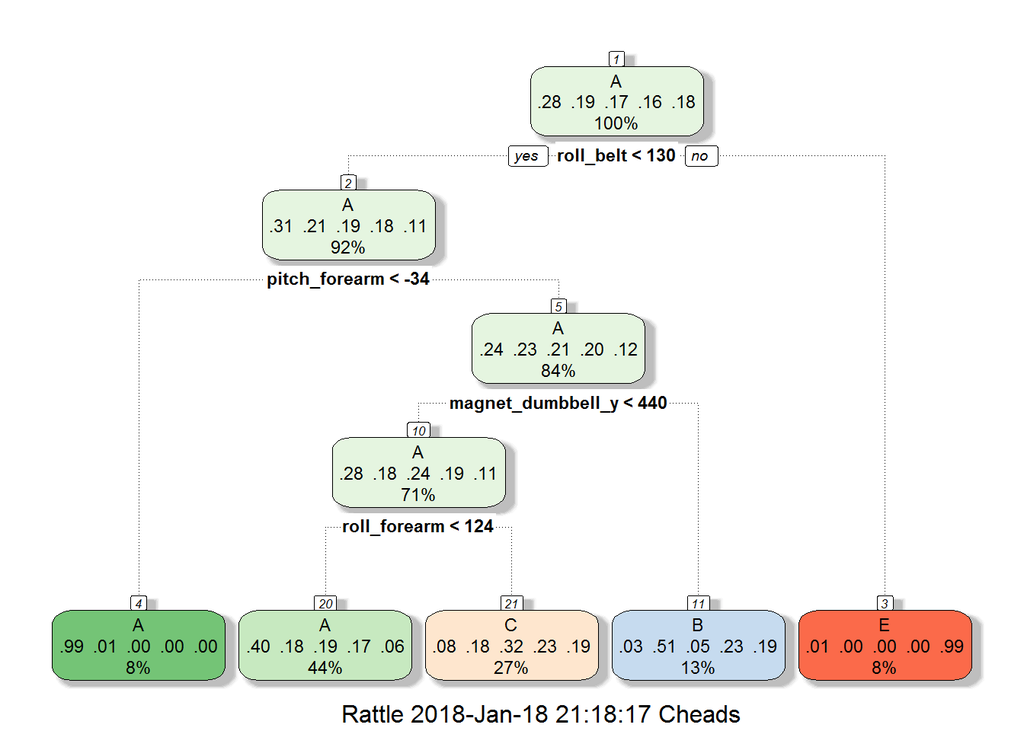

```r
set.seed(86)
train_control <- trainControl(method="cv", number=5)
mod_rpart <- train(classe ~ ., method="rpart",
                   trControl = train_control,
                   data=training)

fancyRpartPlot(mod_rpart$finalModel)
```

Our initial decision tree does an acceptable job splitting out group E, but has trouble with the other groups (and does not even include D).

To obtain the accuracy of the model, I predict with the validation data set, then calculate the confusion matrix.

```r
pred_rpart <- predict(mod_rpart,validation)
confm_rpart <- confusionMatrix(validation$classe, pred_rpart)
confm_rpart
```

```
## Confusion Matrix and Statistics
##
##           Reference
## Prediction    A    B    C    D    E
##          A 1073   16   85    0    5
##          B  332  262  206    0    0
##          C  348   25  355    0    0
##          D  306  110  264    0    0
##          E  109   94  207    0  323
##
## Overall Statistics
##
##                Accuracy : 0.4886
##                  95% CI : (0.4732, 0.504)
##     No Information Rate : 0.5262
##     P-Value [Acc > NIR] : 1
##
##                   Kappa : 0.3301
##  Mcnemar's Test P-Value : NA
##
## Statistics by Class:
##
##                      Class: A Class: B Class: C Class: D Class: E
## Sensitivity            0.4949  0.51677  0.31782       NA  0.98476
## Specificity            0.9457  0.85109  0.87579    0.835  0.89188
## Pos Pred Value         0.9101  0.32750  0.48764       NA  0.44065
## Neg Pred Value         0.6277  0.92620  0.77535       NA  0.99852
## Prevalence             0.5262  0.12306  0.27112    0.000  0.07961
## Detection Rate         0.2604  0.06359  0.08617    0.000  0.07840
## Detection Prevalence   0.2862  0.19417  0.17670    0.165  0.17791
## Balanced Accuracy      0.7203  0.68393  0.59680       NA  0.93832
```

Next we move to the random forest model

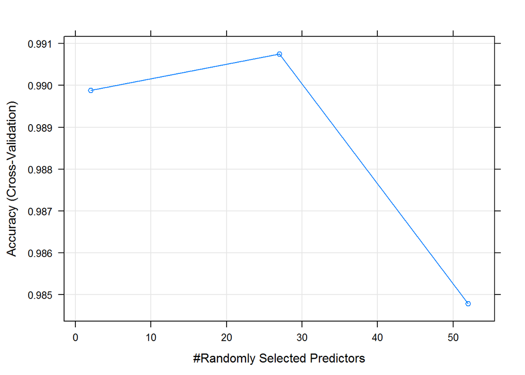

```r
mod_rf <- train(classe ~ ., method="rf",
                   trControl = train_control,
                   data = training,
                   prox = TRUE)

plot(mod_rf)
```

A simple plot shows an accuracy peak at ~28 predictors.

```r
pred_rf <- predict(mod_rf,validation)
confm_rf <- confusionMatrix(validation$classe, pred_rf)
confm_rf
```

```
## Confusion Matrix and Statistics
##
##           Reference
## Prediction    A    B    C    D    E
##          A 1179    0    0    0    0
##          B    0  800    0    0    0
##          C    0    0  728    0    0
##          D    0    0    0  680    0
##          E    0    0    0    0  733
##
## Overall Statistics
##
##                Accuracy : 1
##                  95% CI : (0.9991, 1)
##     No Information Rate : 0.2862
##     P-Value [Acc > NIR] : < 2.2e-16
##
##                   Kappa : 1
##  Mcnemar's Test P-Value : NA
##
## Statistics by Class:
##
##                      Class: A Class: B Class: C Class: D Class: E
## Sensitivity            1.0000   1.0000   1.0000    1.000   1.0000
## Specificity            1.0000   1.0000   1.0000    1.000   1.0000
## Pos Pred Value         1.0000   1.0000   1.0000    1.000   1.0000
## Neg Pred Value         1.0000   1.0000   1.0000    1.000   1.0000
## Prevalence             0.2862   0.1942   0.1767    0.165   0.1779
## Detection Rate         0.2862   0.1942   0.1767    0.165   0.1779
## Detection Prevalence   0.2862   0.1942   0.1767    0.165   0.1779
## Balanced Accuracy      1.0000   1.0000   1.0000    1.000   1.0000
```

The accuracy is shown to be 1, giving us an out-of-sample error rate of 0.

## Evaluation on Test Set

Training and testing data sets must be processed in the same way. Therefore, all processing we performed on the training set is performed on the test set:

```r
na_count <-sapply(testing, function(y) sum(length(which(is.na(y)))))

nas <- sapply(na_count, function(y) y==20) # Change the number of NAs to reflect testing set size
testing <- testing[,nas==FALSE]
sum(is.na(training))
```

```
## [1] 0
```

```r
# Seems like the first 7 variables are impertinent
testing <- testing[,-c(1:7)]

## Near-zero Variance
nzvtest <- nearZeroVar(testing, saveMetrics = TRUE)
sum(nzvtest$nzv)
```

```
## [1] 0
```

```r
# No near-zero variables so we don't include.
```

The test set has the variable ‘problem_id’ instead of ‘classe’ so we can’t get a confusion matrix and therefore assess accuracy. This test set is specifically for the quiz for the Practical Machine Learning class at Coursera.

```r
pred_rf_test <- predict(mod_rf,testing)
solutions <- as.data.frame(cbind(testing$problem_id,
                                 as.character(pred_rf_test)))
colnames(solutions) <- c("Problem ID","Answer")
solutions
```

```
##    Problem ID Answer
## 1           1      B
## 2           2      A
## 3           3      B
## 4           4      A
## 5           5      A
## 6           6      E
## 7           7      D
## 8           8      B
## 9           9      A
## 10         10      A
## 11         11      B
## 12         12      C
## 13         13      B
## 14         14      A
## 15         15      E
## 16         16      E
## 17         17      A
## 18         18      B
## 19         19      B
## 20         20      B
```